# IE 582 - Homework II

### Seval Ata

#### 01.11.2019

# Task 1

### Multiple Instance Learning

**Part A**

*Necessary libraries*

```r
library(dplyr)
library(ggplot2)
library(plotly)
```

*Reading the data*

```r
file_path="/Users/Seval/Desktop/Musk1.csv"
musk = read.csv(file_path, header = FALSE)
```

*PCA analysis of the data by standardizing the data.*

```r
musk_rev <-musk[,-c(1,2)] #removing the first two columns because they are not going to bu used in PCA analysis
pca_musk = prcomp(musk_rev, scale. = TRUE, center = TRUE)
```

```r
summary(pca_musk)
```

```
Importance of components:
                          PC1    PC2     PC3     PC4    PC5     PC6     PC7
Standard deviation     7.1953 4.8073 3.55611 2.92189 2.8577 2.60187 2.32140
Proportion of Variance 0.3119 0.1392 0.07618 0.05143 0.0492 0.04078 0.03246
Cumulative Proportion  0.3119 0.4511 0.52728 0.57871 0.6279 0.66869 0.70115
                           PC8     PC9    PC10    PC11    PC12   PC13   PC14
Standard deviation     2.24739 1.81832 1.68833 1.60356 1.54167 1.4858 1.4521
Proportion of Variance 0.03043 0.01992 0.01717 0.01549 0.01432 0.0133 0.0127
Cumulative Proportion  0.73158 0.75150 0.76867 0.78416 0.79848 0.8118 0.8245
                          PC15    PC16    PC17    PC18    PC19    PC20    PC21
Standard deviation     1.34647 1.28737 1.19887 1.16425 1.12078 1.08869 1.05904
Proportion of Variance 0.01092 0.00998 0.00866 0.00817 0.00757 0.00714 0.00676
Cumulative Proportion  0.83540 0.84538 0.85404 0.86221 0.86977 0.87691 0.88367
                          PC22    PC23    PC24    PC25    PC26    PC27    PC28
Standard deviation     1.02828 1.02427 0.98442 0.96337 0.93192 0.90624 0.90126
Proportion of Variance 0.00637 0.00632 0.00584 0.00559 0.00523 0.00495 0.00489
Cumulative Proportion  0.89004 0.89636 0.90220 0.90779 0.91302 0.91797 0.92286
                          PC29    PC30    PC31    PC32    PC33    PC34    PC35
Standard deviation     0.88045 0.85752 0.81566 0.81411 0.79888 0.74294 0.69801
Proportion of Variance 0.00467 0.00443 0.00401 0.00399 0.00384 0.00333 0.00294
Cumulative Proportion  0.92753 0.93196 0.93597 0.93996 0.94381 0.94713 0.95007
                          PC36    PC37    PC38    PC39    PC40   PC41    PC42
Standard deviation     0.68643 0.66519 0.64867 0.63555 0.58365 0.5764 0.55650
Proportion of Variance 0.00284 0.00267 0.00253 0.00243 0.00205 0.0020 0.00187
Cumulative Proportion  0.95290 0.95557 0.95810 0.96054 0.96259 0.9646 0.96646
                          PC43    PC44    PC45    PC46    PC47    PC48    PC49
Standard deviation     0.54415 0.52406 0.51901 0.49766 0.48888 0.47363 0.45296
Proportion of Variance 0.00178 0.00165 0.00162 0.00149 0.00144 0.00135 0.00124
Cumulative Proportion  0.96824 0.96989 0.97152 0.97301 0.97445 0.97580 0.97704
                          PC50    PC51    PC52    PC53    PC54   PC55    PC56
Standard deviation     0.44507 0.43473 0.42344 0.41542 0.39910 0.3873 0.37953
Proportion of Variance 0.00119 0.00114 0.00108 0.00104 0.00096 0.0009 0.00087
Cumulative Proportion  0.97823 0.97937 0.98045 0.98149 0.98245 0.9833 0.98422
                          PC57    PC58    PC59    PC60    PC61    PC62    PC63
Standard deviation     0.37076 0.35919 0.35466 0.34350 0.32578 0.32031 0.30165
Proportion of Variance 0.00083 0.00078 0.00076 0.00071 0.00064 0.00062 0.00055
Cumulative Proportion  0.98505 0.98582 0.98658 0.98729 0.98793 0.98855 0.98910
                          PC64    PC65    PC66    PC67    PC68   PC69    PC70
Standard deviation     0.30006 0.29339 0.27945 0.27484 0.26429 0.2564 0.24948
Proportion of Variance 0.00054 0.00052 0.00047 0.00046 0.00042 0.0004 0.00037
```

[output cut: 42 more lines]

```
Standard deviation     0.04397 0.04010 0.03948 0.03885 0.03695 0.03636 0.03458
Proportion of Variance 0.00001 0.00001 0.00001 0.00001 0.00001 0.00001 0.00001
Cumulative Proportion  0.99988 0.99989 0.99990 0.99991 0.99992 0.99993 0.99993
                         PC148   PC149   PC150   PC151   PC152   PC153   PC154
Standard deviation     0.03423 0.03374 0.03181 0.03071 0.02865 0.02771 0.02745
Proportion of Variance 0.00001 0.00001 0.00001 0.00001 0.00000 0.00000 0.00000
Cumulative Proportion  0.99994 0.99995 0.99995 0.99996 0.99996 0.99997 0.99997
                         PC155   PC156  PC157   PC158  PC159   PC160   PC161
Standard deviation     0.02487 0.02426 0.0234 0.02284 0.0209 0.01934 0.01787
Proportion of Variance 0.00000 0.00000 0.0000 0.00000 0.0000 0.00000 0.00000
Cumulative Proportion  0.99998 0.99998 1.0000 0.99999 1.0000 0.99999 0.99999
                         PC162  PC163   PC164   PC165 PC166
Standard deviation     0.01723 0.0167 0.01411 0.01332 0.011
Proportion of Variance 0.00000 0.0000 0.00000 0.00000 0.000
Cumulative Proportion  1.00000 1.0000 1.00000 1.00000 1.000
```

```r
variance_musk <- pca_musk$sdev^2 #Variance
var_exp_musk=100 * variance_musk / sum(variance_musk) #  percentage variation explained
```

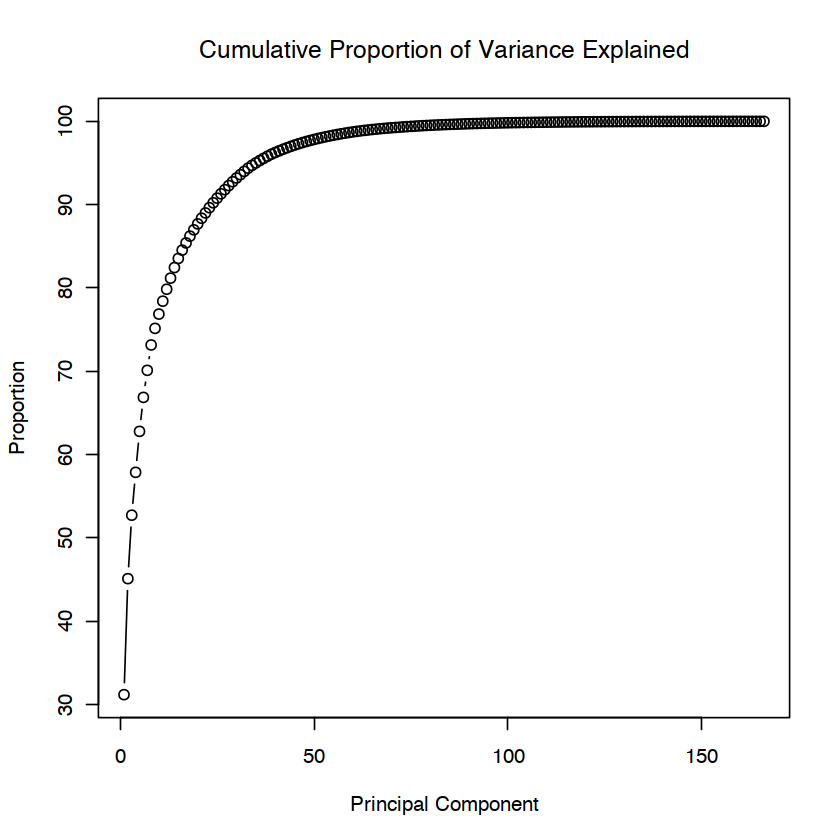

```r
plot(cumsum(var_exp_musk), main = "Cumulative Proportion of Variance Explained", xlab = "Principal Component",
              ylab = "Proportion",
              type = "b")
```

**As we can see, the first 3 components cover 52% of the variance and the first 12 components cover the 80% variance of the data. According to the plot above, it is not necessary to use more than 50 variables since the remanining variables does not contribute to the explained variable significantly.**

We can plot reduced dimensions on the following figures in which instances are color-coded with their bag labels.

```r
pca_musk_3 = pca_musk$x[,1:3]
```

```r
head(pca_musk_3)
```

A matrix: 6 × 3 of type dbl

| PC1 | PC2 | PC3 |
| --- | --- | --- |
| -0.7870220 | -8.655373 | -2.43062015 |
| -0.7816826 | -8.535124 | -2.63326679 |
| -0.2478201 | -8.351507 | -2.45185223 |
| -1.3549969 | -9.096528 | -2.63635288 |
| -1.4575178 | -8.675879 | 0.01666451 |
| -1.4311819 | -8.514454 | -0.18698801 |

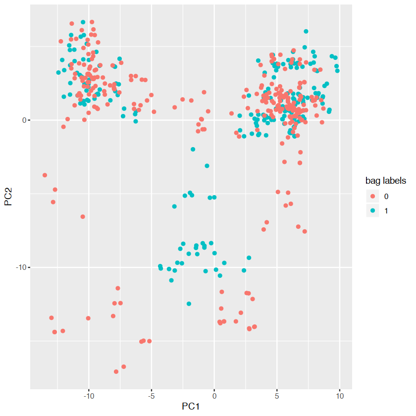

```r
inst_labels = as.factor(musk$V1)
pca_musk_3.df=as.data.frame(pca_musk_3)
pca_musk_3.df %>%
    ggplot(aes(PC1, PC2, col = inst_labels)) +
  geom_point() +
  labs(col = "bag labels")
```

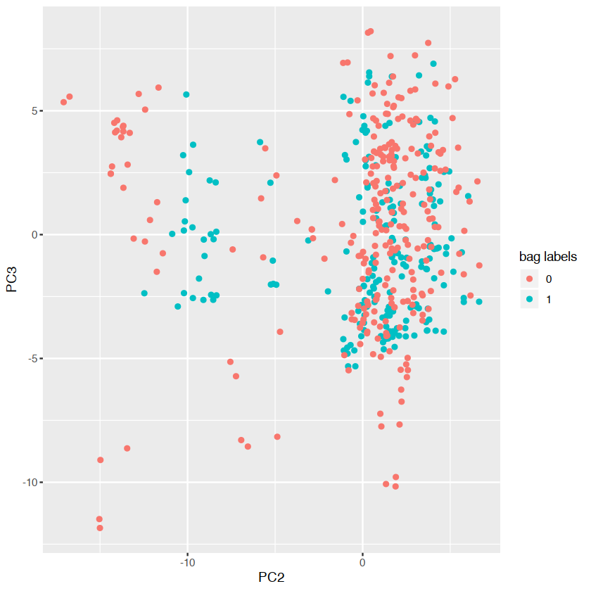

```r
pca_musk_3.df %>%
    ggplot(aes(PC2, PC3, col = inst_labels)) +
  geom_point() +
  labs(col = "bag labels")
```

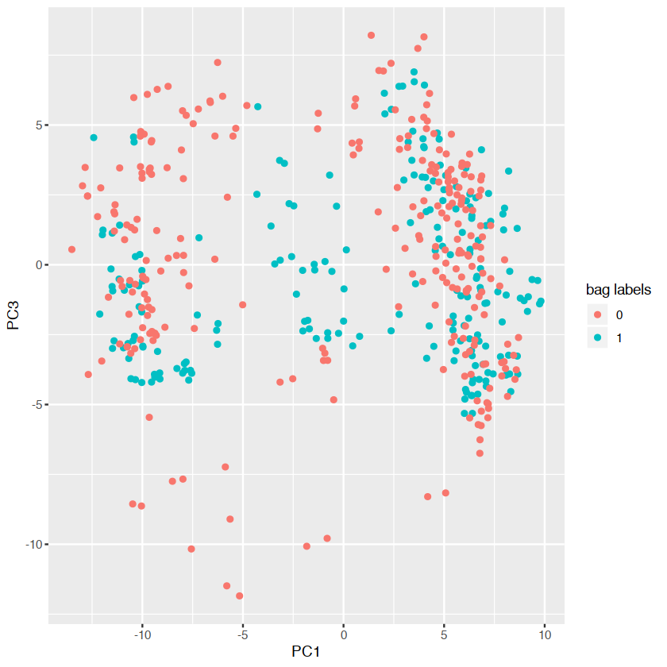

```r
pca_musk_3.df %>%
    ggplot(aes(PC1, PC3, col = inst_labels)) +
  geom_point() +
  labs(col = "bag labels")
```

**In the plots given above, the first 3 component is plotted and we couldn't obtain a significant distinction. Therefore, we can conclude that assumption of the instance labels’ being as the same as bag labels is not an efficient solution.**

*Applying MDS after scaling the data.*

```r
musk_rev_mat=as.matrix(musk_rev)
scaled_musk_rev_mat=scale(musk_rev_mat)
dist_mat=dist(scaled_musk_rev_mat)
mds_musk_3=as.data.frame(cmdscale(dist_mat, k=3))
```

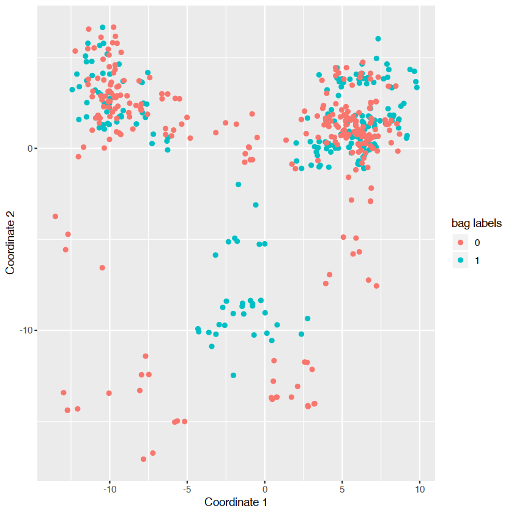

```r
mds_musk_3 %>%
  ggplot(aes(x = mds_musk_3[,1], y = mds_musk_3[,2], col = inst_labels)) +
  geom_point() +
  labs(x = "Coordinate 1", y = "Coordinate 2", col = "bag labels")
```

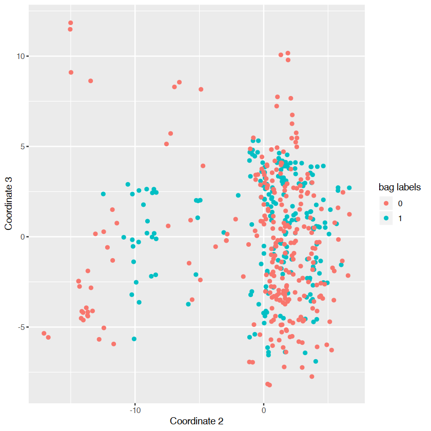

```r
mds_musk_3 %>%
  ggplot(aes(x = mds_musk_3[,2], y = mds_musk_3[,3], col = inst_labels)) +
  geom_point() +
  labs(x = "Coordinate 2", y = "Coordinate 3", col = "bag labels")
```

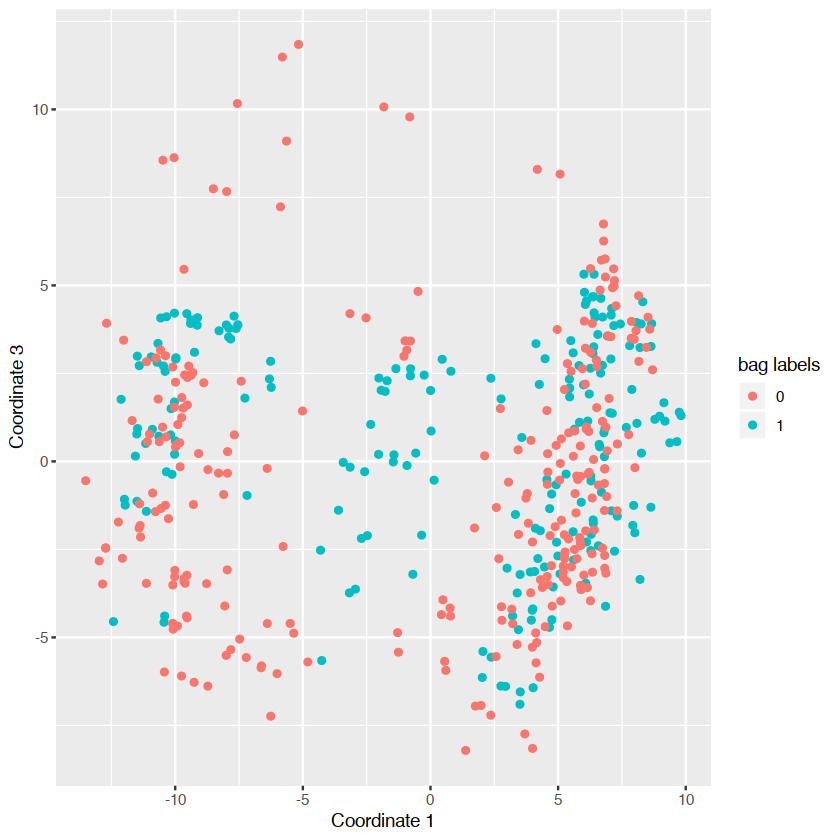

```r
mds_musk_3 %>%
  ggplot(aes(x = mds_musk_3[,1], y = mds_musk_3[,3], col = inst_labels)) +
  geom_point() +
  labs(x = "Coordinate 1", y = "Coordinate 3", col = "bag labels")
```

**As we observed in the PCA case, we still can not obtain a significant distinction. Therefore, we can conclude that assumption of the instance labels’ being as the same as bag labels is not an efficient solution for MDS, too.**

**Part B**

*Taking the average of the instance features so that the bag is represented by the center of its instances.*

```r
musk_mean = musk %>% group_by(V2) %>%
  summarise_all(funs(mean)) %>%
  ungroup() %>%
  select(-(V1:V2))
```

```r
bag_labels = musk %>%
  group_by(V2) %>%
  summarise(V1 = head(V1,1))
```

*Applying PCA*

```r
bag_labels = as.factor(bag_labels$V1)

pca_centered = prcomp(musk_mean, scale. = TRUE, center = TRUE)
pca_centered_3 = pca_centered$x[,1:3]
pca_centered_3.df=as.data.frame(pca_centered_3)
```

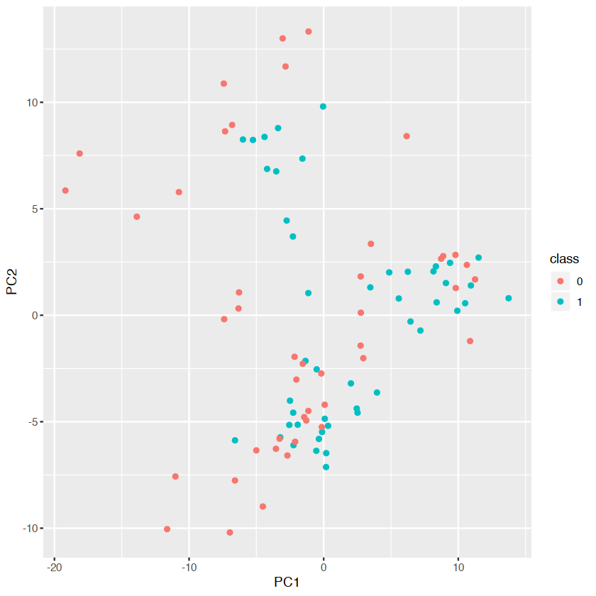

```r
ggplot(pca_centered_3.df, aes(PC1, PC2, col = bag_labels))  +
  geom_point() +
  labs(col = "class")
```

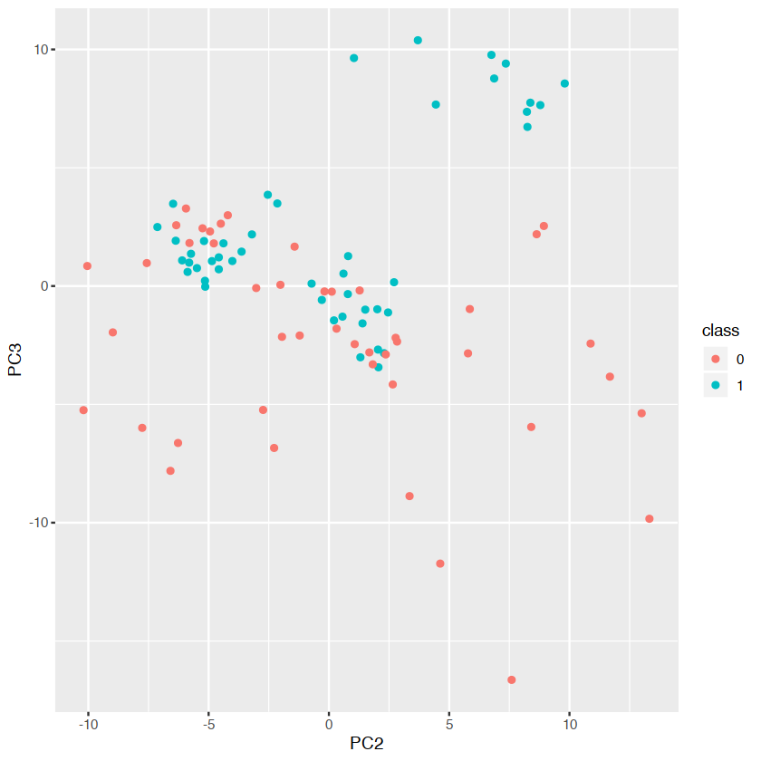

```r
ggplot(pca_centered_3.df, aes(PC2, PC3, col = bag_labels))  +
  geom_point() +
  labs(col = "class")
```

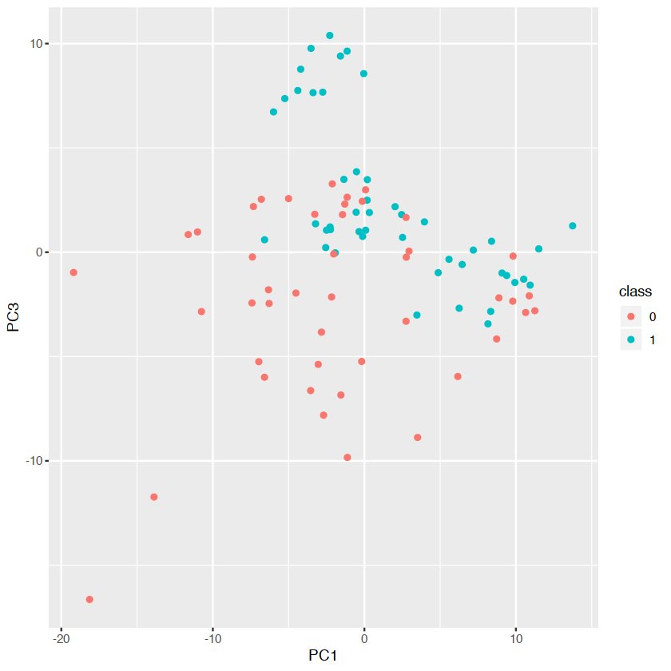

```r
ggplot(pca_centered_3.df, aes(PC1, PC3, col = bag_labels))  +
  geom_point() +
  labs(col = "class")
```

**Still we don't have a significant separation. Therefore, we can conclude that averaging the instance features is not an efficient solution.**

```r
variance_musk_centered <- pca_centered$sdev^2 #Variance
var_exp_musk_centered=100 * variance_musk_centered / sum(variance_musk_centered) #  percentage variation explained
```

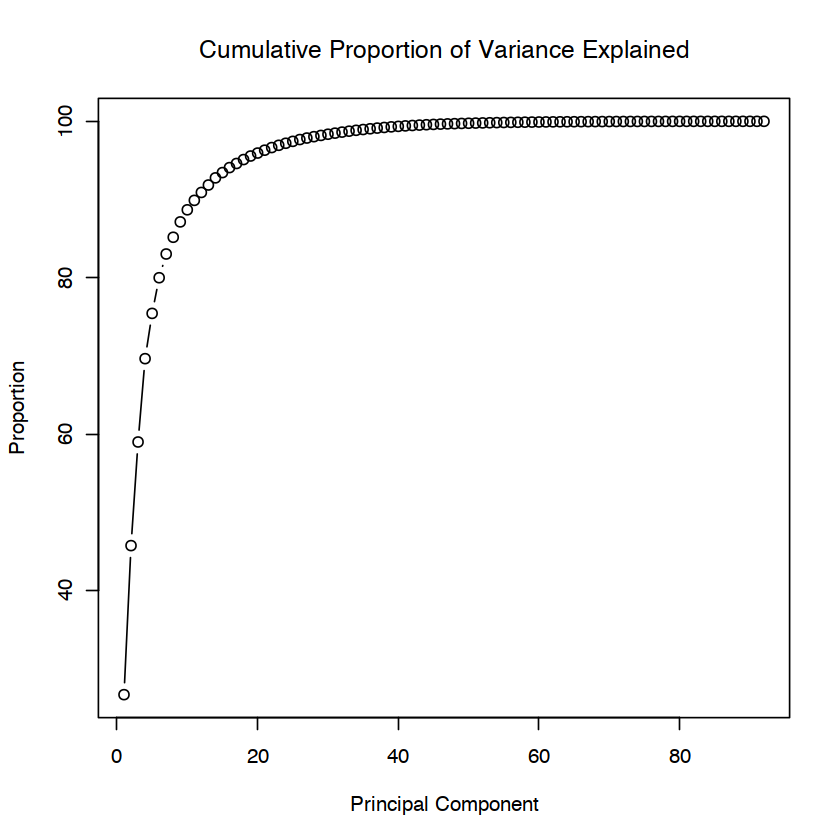

```r
plot(cumsum(var_exp_musk_centered), main = "Cumulative Proportion of Variance Explained", xlab = "Principal Component",
              ylab = "Proportion",
              type = "b")
```

```r
summary(pca_centered)
```

```
Importance of components:
                          PC1    PC2    PC3    PC4     PC5     PC6     PC7
Standard deviation     6.6528 5.6257 4.6908 4.2063 3.10049 2.75154 2.24499
Proportion of Variance 0.2666 0.1907 0.1326 0.1066 0.05791 0.04561 0.03036
Cumulative Proportion  0.2666 0.4573 0.5898 0.6964 0.75433 0.79993 0.83030
                           PC8     PC9    PC10    PC11    PC12   PC13    PC14
Standard deviation     1.88542 1.80613 1.60162 1.41639 1.29688 1.2561 1.23131
Proportion of Variance 0.02141 0.01965 0.01545 0.01209 0.01013 0.0095 0.00913
Cumulative Proportion  0.85171 0.87136 0.88681 0.89890 0.90903 0.9185 0.92767
                          PC15    PC16    PC17    PC18    PC19    PC20    PC21
Standard deviation     1.05946 1.02942 0.93512 0.91230 0.86691 0.79297 0.78039
Proportion of Variance 0.00676 0.00638 0.00527 0.00501 0.00453 0.00379 0.00367
Cumulative Proportion  0.93443 0.94081 0.94608 0.95110 0.95562 0.95941 0.96308
                          PC22   PC23    PC24    PC25    PC26    PC27    PC28
Standard deviation     0.74704 0.6937 0.65812 0.63570 0.62054 0.56340 0.53876
Proportion of Variance 0.00336 0.0029 0.00261 0.00243 0.00232 0.00191 0.00175
Cumulative Proportion  0.96644 0.9693 0.97195 0.97438 0.97670 0.97862 0.98036
                         PC29    PC30    PC31    PC32    PC33    PC34    PC35
Standard deviation     0.5149 0.50515 0.48016 0.46820 0.44470 0.42894 0.40874
Proportion of Variance 0.0016 0.00154 0.00139 0.00132 0.00119 0.00111 0.00101
Cumulative Proportion  0.9820 0.98350 0.98489 0.98621 0.98740 0.98851 0.98951
                          PC36    PC37   PC38    PC39    PC40    PC41    PC42
Standard deviation     0.39965 0.38054 0.3643 0.36024 0.32250 0.31709 0.29101
Proportion of Variance 0.00096 0.00087 0.0008 0.00078 0.00063 0.00061 0.00051
Cumulative Proportion  0.99048 0.99135 0.9921 0.99293 0.99356 0.99416 0.99467
                          PC43    PC44   PC45    PC46    PC47    PC48    PC49
Standard deviation     0.28987 0.27843 0.2579 0.25075 0.22941 0.21491 0.21031
Proportion of Variance 0.00051 0.00047 0.0004 0.00038 0.00032 0.00028 0.00027
Cumulative Proportion  0.99518 0.99565 0.9960 0.99643 0.99674 0.99702 0.99729
                          PC50    PC51    PC52   PC53    PC54    PC55    PC56
Standard deviation     0.19940 0.19567 0.18698 0.1828 0.17357 0.16440 0.15556
Proportion of Variance 0.00024 0.00023 0.00021 0.0002 0.00018 0.00016 0.00015
Cumulative Proportion  0.99753 0.99776 0.99797 0.9982 0.99835 0.99851 0.99866
                          PC57    PC58    PC59   PC60    PC61    PC62    PC63
Standard deviation     0.15071 0.14823 0.13348 0.1277 0.12491 0.11920 0.11037
Proportion of Variance 0.00014 0.00013 0.00011 0.0001 0.00009 0.00009 0.00007
Cumulative Proportion  0.99880 0.99893 0.99904 0.9991 0.99923 0.99931 0.99939
                          PC64    PC65    PC66    PC67    PC68    PC69    PC70
Standard deviation     0.09867 0.09513 0.09437 0.09016 0.08776 0.08368 0.07755
Proportion of Variance 0.00006 0.00005 0.00005 0.00005 0.00005 0.00004 0.00004
Cumulative Proportion  0.99945 0.99950 0.99955 0.99960 0.99965 0.99969 0.99973
                          PC71    PC72    PC73    PC74    PC75    PC76    PC77
Standard deviation     0.07694 0.07280 0.06549 0.06194 0.06145 0.05420 0.05184
Proportion of Variance 0.00004 0.00003 0.00003 0.00002 0.00002 0.00002 0.00002
Cumulative Proportion  0.99976 0.99979 0.99982 0.99984 0.99987 0.99988 0.99990
                          PC78    PC79    PC80    PC81    PC82    PC83    PC84
Standard deviation     0.04933 0.04641 0.04430 0.04222 0.04009 0.03499 0.03489
Proportion of Variance 0.00001 0.00001 0.00001 0.00001 0.00001 0.00001 0.00001
Cumulative Proportion  0.99992 0.99993 0.99994 0.99995 0.99996 0.99997 0.99998
                          PC85    PC86    PC87    PC88    PC89   PC90    PC91
Standard deviation     0.03129 0.02695 0.02536 0.02481 0.02177 0.0201 0.01676
Proportion of Variance 0.00001 0.00000 0.00000 0.00000 0.00000 0.0000 0.00000
Cumulative Proportion  0.99998 0.99999 0.99999 0.99999 1.00000 1.0000 1.00000
                            PC92
Standard deviation     6.493e-16
Proportion of Variance 0.000e+00
Cumulative Proportion  1.000e+00
```

**However, we can explain a higher amount of variation in the data in this way. We can explain 75% of the variance with first 5 component and 80% of the variance with first 6 component.**

*Applying MDS on the data after scaling.*

```r
musk_scaled_centered = musk_mean %>%
  as.matrix() %>%
  scale()

dist_mat_centered = dist(musk_scaled_centered)
mds_centered = cmdscale(dist_mat_centered, k=3)
```

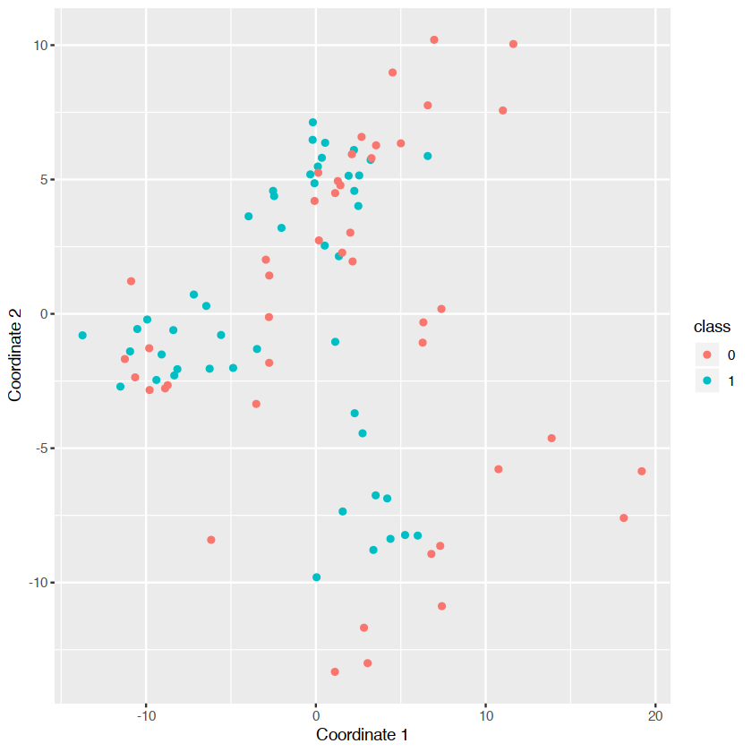

```r
mds_centered %>% as.data.frame() %>%
  ggplot(aes(mds_centered[,1], mds_centered[,2], col = bag_labels)) +
  geom_point() +
  labs(x = "Coordinate 1", y = "Coordinate 2", col = "class")
```

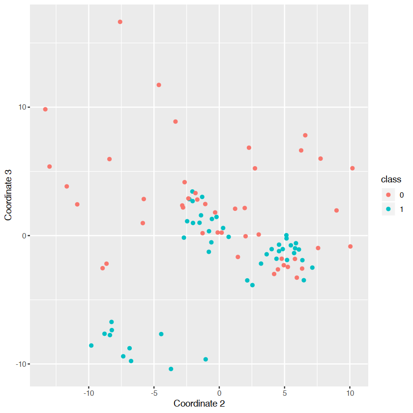

```r
mds_centered %>% as.data.frame() %>%
  ggplot(aes(mds_centered[,2], mds_centered[,3], col = bag_labels)) +
  geom_point() +
  labs(x = "Coordinate 2", y = "Coordinate 3", col = "class")
```

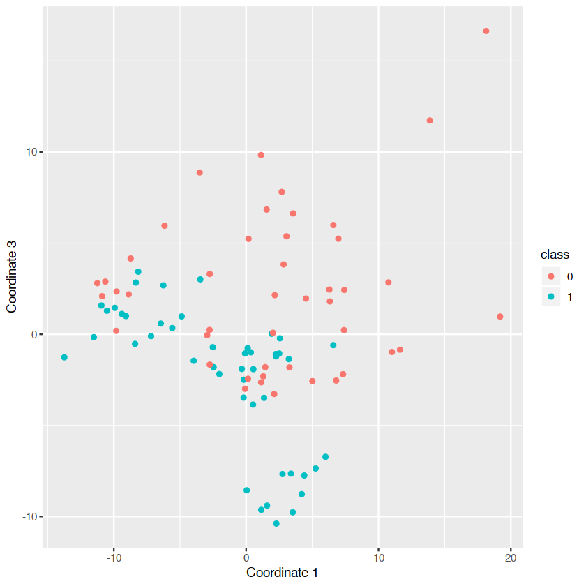

```r
mds_centered %>% as.data.frame() %>%
  ggplot(aes(mds_centered[,1], mds_centered[,3], col = bag_labels)) +
  geom_point() +
  labs(x = "Coordinate 1", y = "Coordinate 3", col = "class")
```

**We can observe the same situation as in the case of PCA. It is not a good transformation approach for classifying bags.**

**Part C**

We can represent each bag with the median of the instances. In this way we don't need to make extra calculations. Also, since choosing median has an advantage of getting rid of the outliers, it might give better results.

# Task 2

Here, the aim is to compress images using PCA.

*Necessary libraries*

```r
library(jpeg)
library(grid)
```

*Loading the image*

```r
image_path="/Users/Seval/Desktop/Seval_256.jpg"
image<-readJPEG(image_path)
image.df <- as.data.frame(image)
image.df
```

A data.frame: 256 × 768

[output not shown]

*Displaying the image*

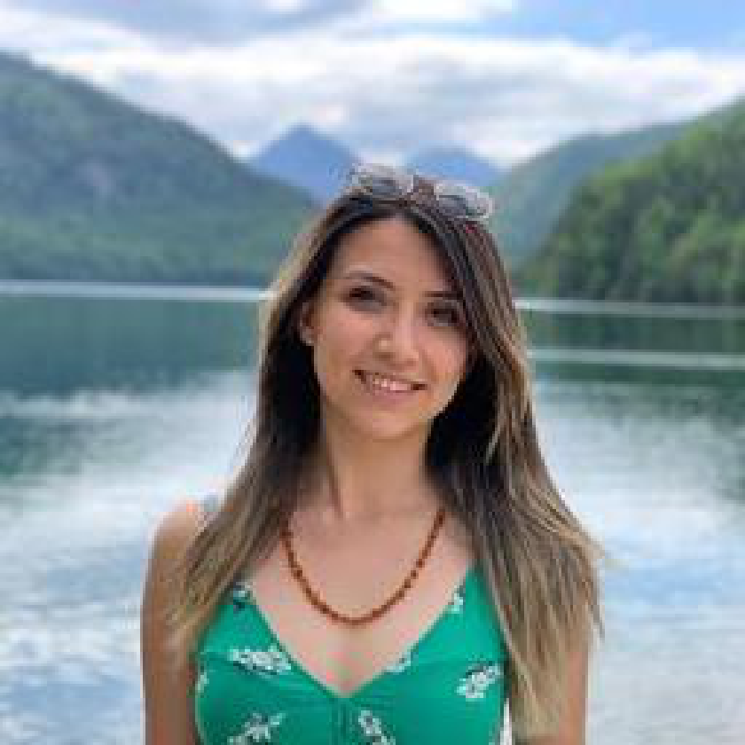

```r
r <- image[,,1]
g <- image[,,2]
b <- image[,,3]

col <- rgb(r, g, b)
dim(col) <- dim(r)
grid.raster(col, interpolate=FALSE)
```

*Adding noise*

```r
r_noise <- runif(dim(r)[1]*dim(r)[2], min(r), 0.1*max(r))
r_noise_matrix=matrix(r_noise,dim(r)[1],dim(r)[2])

g_noise <- runif(dim(g)[1]*dim(g)[2], min(g), 0.1*max(g))
g_noise_matrix=matrix(g_noise,dim(g)[1],dim(g)[2])

b_noise <- runif(dim(b)[1]*dim(b)[2], min(b), 0.1*max(b))
b_noise_matrix=matrix(b_noise,dim(b)[1],dim(b)[2])

r_new <- r + r_noise_matrix
g_new <- g + g_noise_matrix
b_new <- b + b_noise_matrix
```

```r
for (i in 1:256){
    for(j in 1:256)
        {
        if(r_new[i,j]>1)
            {
            r_new[i,j]=1
        }
    }
}

for (i in 1:256){
    for(j in 1:256)
        {
        if(g_new[i,j]>1)
            {
            g_new[i,j]=1
        }
    }
}

for (i in 1:256){
    for(j in 1:256)
        {
        if(b_new[i,j]>1)
            {
            b_new[i,j]=1
        }
    }
}
```

*Noise added image*

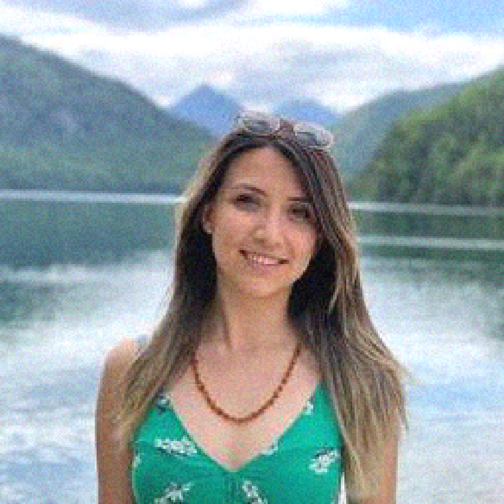

```r
col2 <- rgb(r_new,g_new,b_new)
dim(col2) <- dim(r_new)
grid.raster(col2, interpolate=FALSE)
```

*Red channel*

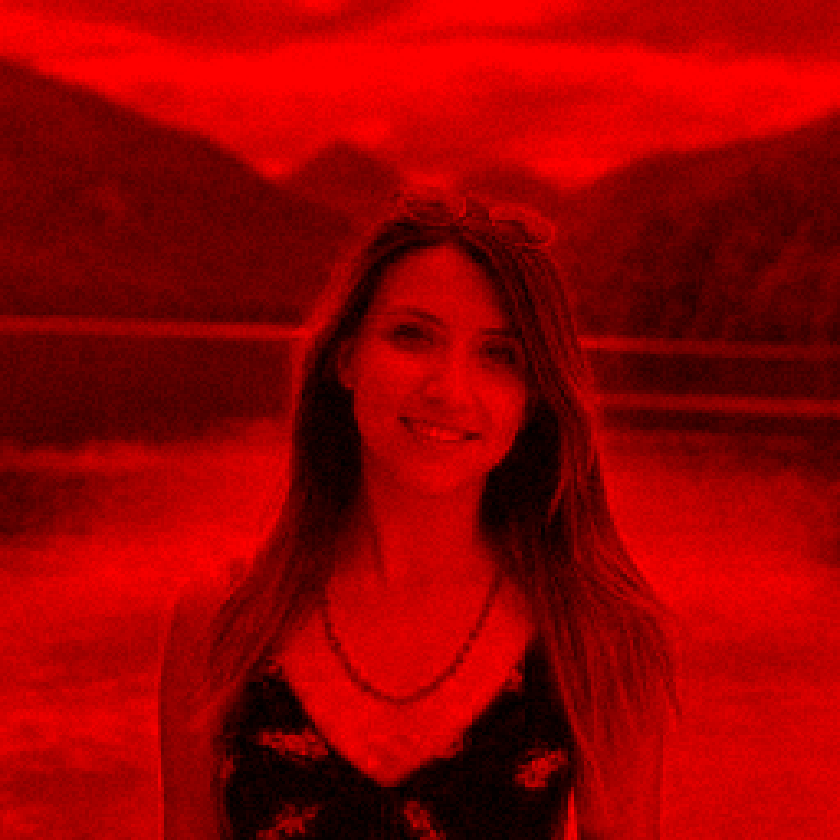

```r
col3 <- rgb(r_new,0,0)
dim(col3) <- dim(r_new)
grid.raster(col3, interpolate=FALSE)
```

*Green channel*

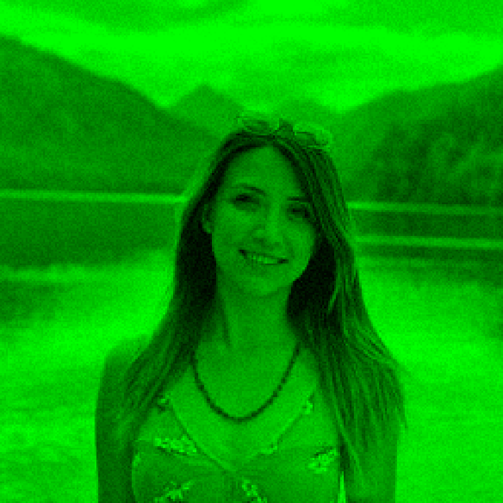

```r
col4 <- rgb(0,g_new,0)
dim(col4) <- dim(g_new)
grid.raster(col4, interpolate=FALSE)
```

*Blue channel*

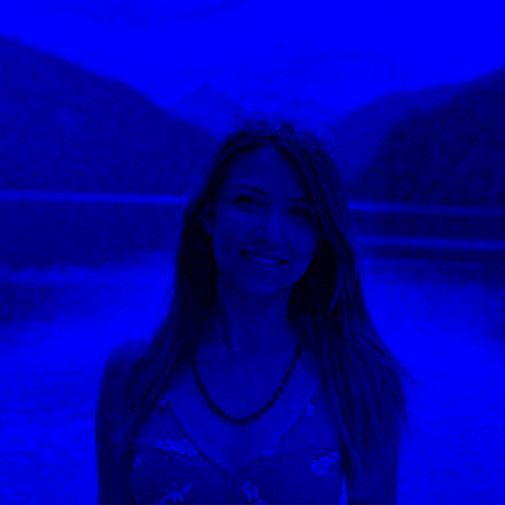

```r
col5 <- rgb(0,0,b_new)
dim(col5) <- dim(b_new)
grid.raster(col5, interpolate=FALSE)
```

*Greyscale noisy image*

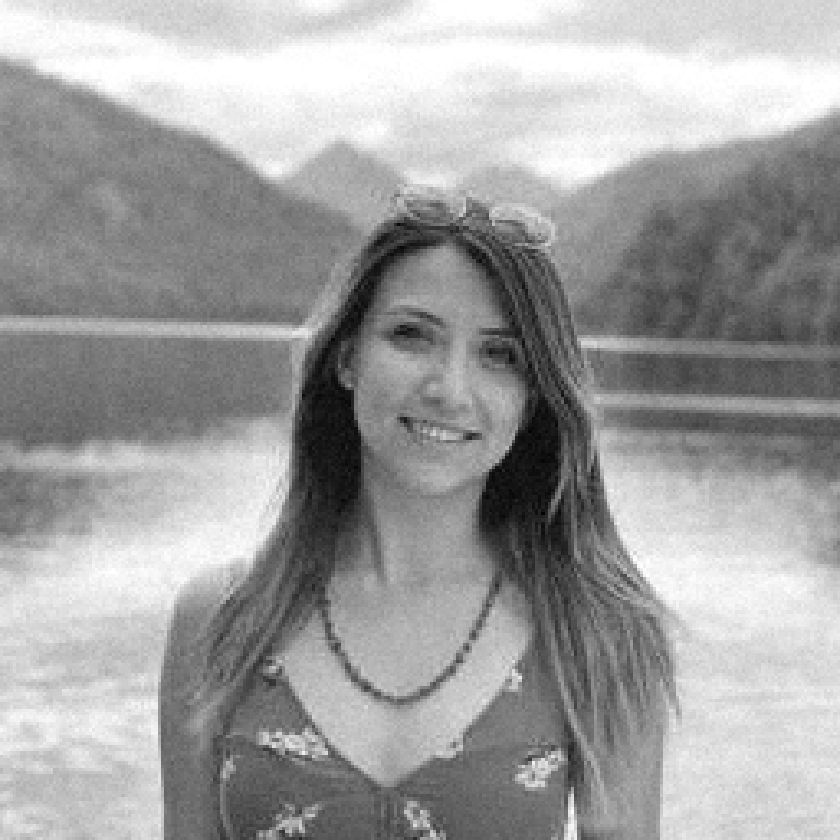

```r
grayscaled<-r_new+g_new+b_new
grayscaled <- grayscaled/max(grayscaled) #converting to greyscale
grid.raster(grayscaled, interpolate=FALSE)
```

*Extracting patches from the image*

```r
patch_size=25
number_of_patches=(256+1-patch_size)^2
number_of_patches
```

53824

```r
dim_of_patches=(patch_size)^2
patch<-array(0, dim=c(dim_of_patches, number_of_patches))
m=0
```

```r
for(j in 1:sqrt(number_of_patches)){
        for(k in 1:sqrt(number_of_patches)){
            temp=grayscaled[j:(j+patch_size-1), k:(k+patch_size-1)]
            patch[,m+1]=array(temp)
            m=m+1
            }
}
```

*Applying PCA to this data matrix of patches*

```r
patchdt=as.data.frame(patch)
pca_image = prcomp(patchdt, scale.=TRUE, center=TRUE)
summary(pca_image)
```

```
Importance of components:
                            PC1     PC2      PC3      PC4      PC5      PC6
Standard deviation     119.3172 94.4592 66.52783 52.50449 48.28090 44.83891
Proportion of Variance   0.2645  0.1658  0.08223  0.05122  0.04331  0.03735
Cumulative Proportion    0.2645  0.4303  0.51251  0.56372  0.60703  0.64439
                            PC7      PC8      PC9     PC10     PC11     PC12
Standard deviation     34.52511 34.18901 30.62265 27.04341 26.98669 25.74885
Proportion of Variance  0.02215  0.02172  0.01742  0.01359  0.01353  0.01232
Cumulative Proportion   0.66653  0.68825  0.70567  0.71926  0.73279  0.74511
                           PC13     PC14     PC15     PC16     PC17     PC18
Standard deviation     23.48290 21.96330 21.04185 19.59273 19.04513 18.44347
Proportion of Variance  0.01025  0.00896  0.00823  0.00713  0.00674  0.00632
Cumulative Proportion   0.75535  0.76431  0.77254  0.77967  0.78641  0.79273
                           PC19     PC20     PC21    PC22     PC23     PC24
Standard deviation     16.98477 16.30245 16.10771 15.3851 15.10354 14.66289
Proportion of Variance  0.00536  0.00494  0.00482  0.0044  0.00424  0.00399
Cumulative Proportion   0.79809  0.80303  0.80785  0.8123  0.81649  0.82048
                           PC25     PC26     PC27     PC28     PC29     PC30
Standard deviation     13.88717 13.61731 12.85902 12.50549 12.42129 11.96827
Proportion of Variance  0.00358  0.00345  0.00307  0.00291  0.00287  0.00266
Cumulative Proportion   0.82406  0.82751  0.83058  0.83349  0.83635  0.83901
                           PC31     PC32     PC33     PC34    PC35     PC36
Standard deviation     11.87197 11.56949 11.22072 10.91336 10.6253 10.51403
Proportion of Variance  0.00262  0.00249  0.00234  0.00221  0.0021  0.00205
Cumulative Proportion   0.84163  0.84412  0.84646  0.84867  0.8508  0.85282
                           PC37     PC38    PC39   PC40    PC41    PC42    PC43
Standard deviation     10.30671 10.03697 9.92286 9.8428 9.61974 9.49187 9.37934
Proportion of Variance  0.00197  0.00187 0.00183 0.0018 0.00172 0.00167 0.00163
Cumulative Proportion   0.85480  0.85667 0.85850 0.8603 0.86202 0.86369 0.86532
                          PC44    PC45    PC46    PC47    PC48    PC49    PC50
Standard deviation     9.23102 9.06436 9.01537 8.85292 8.61734 8.32676 8.15896
Proportion of Variance 0.00158 0.00153 0.00151 0.00146 0.00138 0.00129 0.00124
Cumulative Proportion  0.86691 0.86843 0.86994 0.87140 0.87278 0.87407 0.87530
                          PC51    PC52    PC53    PC54    PC55    PC56    PC57
Standard deviation     8.06581 8.00176 7.96592 7.86045 7.79083 7.60951 7.54756
Proportion of Variance 0.00121 0.00119 0.00118 0.00115 0.00113 0.00108 0.00106
Cumulative Proportion  0.87651 0.87770 0.87888 0.88003 0.88116 0.88223 0.88329
                          PC58    PC59    PC60    PC61    PC62    PC63    PC64
Standard deviation     7.45735 7.27828 7.11211 7.02135 6.99845 6.91568 6.86999
Proportion of Variance 0.00103 0.00098 0.00094 0.00092 0.00091 0.00089 0.00088
```

[output cut: 306 more lines]

```
Standard deviation     2.18071 2.18008 2.17702 2.16721 2.16532 2.16376 2.15203
Proportion of Variance 0.00009 0.00009 0.00009 0.00009 0.00009 0.00009 0.00009
Cumulative Proportion  0.99812 0.99821 0.99829 0.99838 0.99847 0.99856 0.99864
                         PC608   PC609   PC610   PC611   PC612   PC613   PC614
Standard deviation     2.14679 2.13243 2.12944 2.12500 2.11318 2.10540 2.10231
Proportion of Variance 0.00009 0.00008 0.00008 0.00008 0.00008 0.00008 0.00008
Cumulative Proportion  0.99873 0.99881 0.99890 0.99898 0.99906 0.99915 0.99923
                         PC615   PC616   PC617   PC618   PC619   PC620   PC621
Standard deviation     2.09447 2.08819 2.07710 2.07174 2.06323 2.06094 2.04578
Proportion of Variance 0.00008 0.00008 0.00008 0.00008 0.00008 0.00008 0.00008
Cumulative Proportion  0.99931 0.99939 0.99947 0.99955 0.99963 0.99971 0.99979
                         PC622   PC623   PC624     PC625
Standard deviation     2.04433 1.92475 1.91409 1.056e-13
Proportion of Variance 0.00008 0.00007 0.00007 0.000e+00
Cumulative Proportion  0.99986 0.99993 1.00000 1.000e+00
```

```r
variance <- pca_image$sdev^2 #Variance
var_exp=100 * variance / sum(variance) #  percentage variation explained
```

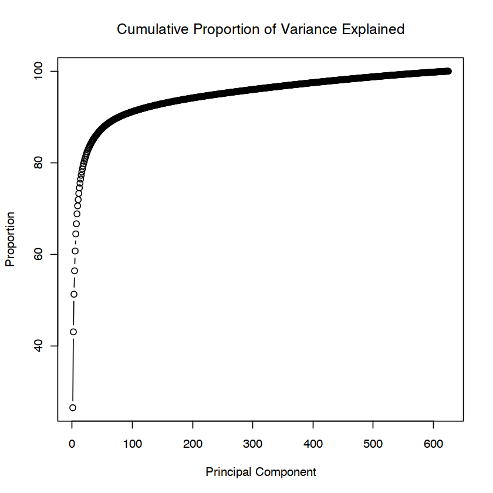

```r
plot(cumsum(var_exp), main = "Cumulative Proportion of Variance Explained", xlab = "Principal Component",
              ylab = "Proportion",
              type = "b")
```

**As we can see, the first 3 components cover 50% of the variance and the first 5 components cover the 60% variance of the data. According to the plot above, it is not necessary to use more than 100 variables since the remanining variables does not contribute to the explained variable significantly.**